# Project: Investigating TMDB Movie Dataset

- Introduction
- Data Wrangling
- Exploratory Data Analysis
- Conclusions

## Introduction

### Dataset Description

> This data set contains information about 10,000 movies collected from The Movie Database (TMDb), including user ratings and revenue.

> Certain columns, like ‘cast’ and ‘genres’, contain multiple values separated by pipe (|) characters. There are some odd characters in the ‘cast’ column. Don’t worry about cleaning them. You can leave them as is. The final two columns ending with “_adj” show the budget and revenue of the associated movie in terms of 2010 dollars, accounting for inflation over time.

### Questions for Analysis

1. How does number of movies compare per release year?
2. Change in revenue generated by movies over the years?
3. In which months were the most/least movies released?
4. Which genre has the highest number of movies?
5. Which director has produced the most movies?
6. How does budget and popularity put in for a particular movie or genre relate with revenue generated? i. Popularity vs revenue ii. Vote Aerage vs Revenue iii. Budget vs Revenue
7. Genre distribution over the years by popularity?
8. Movie runtime analysis: What is the average runtime? How does runtime compare with popularity?
9. What is the correlation between popularity and profit?
10. Movies with the ighest and lowest revenue and their directors?
11. What movies had the highest and least runtime?
12. Characetristics of movies with highest revenues i.e., what were the budgets, who are the actors, under what genres do they fall?

```python
#importing libraries and modules

import pandas as pd
import numpy as np
from datetime import datetime
import matplotlib.pyplot as plt
import ast
import seaborn as sns
%config InlineBackend.figure_format = 'retina'
%matplotlib inline
```

## Data Wrangling

> In this section of the report, we shall load in the data, check for cleanliness, and then trim and clean the dataset for analysis.

```python
#Loading the data
df = pd.read_csv('TMDB.csv')

#output first five rows
df.head()
```

|  | id | imdb_id | popularity | budget | revenue | original_title | cast | homepage | director | tagline | ... | overview | runtime | genres | production_companies | release_date | vote_count | vote_average | release_year | budget_adj | revenue_adj |
| --- | --- | --- | --- | --- | --- | --- | --- | --- | --- | --- | --- | --- | --- | --- | --- | --- | --- | --- | --- | --- | --- |
| 0 | 135397 | tt0369610 | 32.985763 | 150000000 | 1513528810 | Jurassic World | Chris Pratt\|Bryce Dallas Howard\|Irrfan Khan\|Vi... | http://www.jurassicworld.com/ | Colin Trevorrow | The park is open. | ... | Twenty-two years after the events of Jurassic ... | 124 | Action\|Adventure\|Science Fiction\|Thriller | Universal Studios\|Amblin Entertainment\|Legenda... | 6/9/15 | 5562 | 6.5 | 2015 | 1.379999e+08 | 1.392446e+09 |
| 1 | 76341 | tt1392190 | 28.419936 | 150000000 | 378436354 | Mad Max: Fury Road | Tom Hardy\|Charlize Theron\|Hugh Keays-Byrne\|Nic... | http://www.madmaxmovie.com/ | George Miller | What a Lovely Day. | ... | An apocalyptic story set in the furthest reach... | 120 | Action\|Adventure\|Science Fiction\|Thriller | Village Roadshow Pictures\|Kennedy Miller Produ... | 5/13/15 | 6185 | 7.1 | 2015 | 1.379999e+08 | 3.481613e+08 |
| 2 | 262500 | tt2908446 | 13.112507 | 110000000 | 295238201 | Insurgent | Shailene Woodley\|Theo James\|Kate Winslet\|Ansel... | http://www.thedivergentseries.movie/#insurgent | Robert Schwentke | One Choice Can Destroy You | ... | Beatrice Prior must confront her inner demons ... | 119 | Adventure\|Science Fiction\|Thriller | Summit Entertainment\|Mandeville Films\|Red Wago... | 3/18/15 | 2480 | 6.3 | 2015 | 1.012000e+08 | 2.716190e+08 |
| 3 | 140607 | tt2488496 | 11.173104 | 200000000 | 2068178225 | Star Wars: The Force Awakens | Harrison Ford\|Mark Hamill\|Carrie Fisher\|Adam D... | http://www.starwars.com/films/star-wars-episod... | J.J. Abrams | Every generation has a story. | ... | Thirty years after defeating the Galactic Empi... | 136 | Action\|Adventure\|Science Fiction\|Fantasy | Lucasfilm\|Truenorth Productions\|Bad Robot | 12/15/15 | 5292 | 7.5 | 2015 | 1.839999e+08 | 1.902723e+09 |
| 4 | 168259 | tt2820852 | 9.335014 | 190000000 | 1506249360 | Furious 7 | Vin Diesel\|Paul Walker\|Jason Statham\|Michelle ... | http://www.furious7.com/ | James Wan | Vengeance Hits Home | ... | Deckard Shaw seeks revenge against Dominic Tor... | 137 | Action\|Crime\|Thriller | Universal Pictures\|Original Film\|Media Rights ... | 4/1/15 | 2947 | 7.3 | 2015 | 1.747999e+08 | 1.385749e+09 |

5 rows × 21 columns

```python
df.shape
```

```
(10866, 21)
```

```python
df.info()
```

```
<class 'pandas.core.frame.DataFrame'>
RangeIndex: 10866 entries, 0 to 10865
Data columns (total 21 columns):
 #   Column                Non-Null Count  Dtype
---  ------                --------------  -----
 0   id                    10866 non-null  int64
 1   imdb_id               10856 non-null  object
 2   popularity            10866 non-null  float64
 3   budget                10866 non-null  int64
 4   revenue               10866 non-null  int64
 5   original_title        10866 non-null  object
 6   cast                  10790 non-null  object
 7   homepage              2936 non-null   object
 8   director              10822 non-null  object
 9   tagline               8042 non-null   object
 10  keywords              9373 non-null   object
 11  overview              10862 non-null  object
 12  runtime               10866 non-null  int64
 13  genres                10843 non-null  object
 14  production_companies  9836 non-null   object
 15  release_date          10866 non-null  object
 16  vote_count            10866 non-null  int64
 17  vote_average          10866 non-null  float64
 18  release_year          10866 non-null  int64
 19  budget_adj            10866 non-null  float64
 20  revenue_adj           10866 non-null  float64
dtypes: float64(4), int64(6), object(11)
memory usage: 1.7+ MB
```

```python
df.describe()
```

|  | id | popularity | budget | revenue | runtime | vote_count | vote_average | release_year | budget_adj | revenue_adj |
| --- | --- | --- | --- | --- | --- | --- | --- | --- | --- | --- |
| count | 10866.000000 | 10866.000000 | 1.086600e+04 | 1.086600e+04 | 10866.000000 | 10866.000000 | 10866.000000 | 10866.000000 | 1.086600e+04 | 1.086600e+04 |
| mean | 66064.177434 | 0.646441 | 1.462570e+07 | 3.982332e+07 | 102.070863 | 217.389748 | 5.974922 | 2001.322658 | 1.755104e+07 | 5.136436e+07 |
| std | 92130.136561 | 1.000185 | 3.091321e+07 | 1.170035e+08 | 31.381405 | 575.619058 | 0.935142 | 12.812941 | 3.430616e+07 | 1.446325e+08 |
| min | 5.000000 | 0.000065 | 0.000000e+00 | 0.000000e+00 | 0.000000 | 10.000000 | 1.500000 | 1960.000000 | 0.000000e+00 | 0.000000e+00 |
| 25% | 10596.250000 | 0.207583 | 0.000000e+00 | 0.000000e+00 | 90.000000 | 17.000000 | 5.400000 | 1995.000000 | 0.000000e+00 | 0.000000e+00 |
| 50% | 20669.000000 | 0.383856 | 0.000000e+00 | 0.000000e+00 | 99.000000 | 38.000000 | 6.000000 | 2006.000000 | 0.000000e+00 | 0.000000e+00 |
| 75% | 75610.000000 | 0.713817 | 1.500000e+07 | 2.400000e+07 | 111.000000 | 145.750000 | 6.600000 | 2011.000000 | 2.085325e+07 | 3.369710e+07 |
| max | 417859.000000 | 32.985763 | 4.250000e+08 | 2.781506e+09 | 900.000000 | 9767.000000 | 9.200000 | 2015.000000 | 4.250000e+08 | 2.827124e+09 |

### Data Cleaning

```python
# Display the number of missing values for each column .
df.isnull().sum()
```

```
id                         0
imdb_id                   10
popularity                 0
budget                     0
revenue                    0
original_title             0
cast                      76
homepage                7930
director                  44
tagline                 2824
keywords                1493
overview                   4
runtime                    0
genres                    23
production_companies    1030
release_date               0
vote_count                 0
vote_average               0
release_year               0
budget_adj                 0
revenue_adj                0
dtype: int64
```

```python
# Dropping the missing values on 'genre' column
df.dropna(how='any', subset=['genres'], inplace=True)
```

```python
#Confirming the outcome of our actions
df.isnull().sum()
```

```
id                         0
imdb_id                    8
popularity                 0
budget                     0
revenue                    0
original_title             0
cast                      75
homepage                7912
director                  42
tagline                 2806
keywords                1475
overview                   3
runtime                    0
genres                     0
production_companies    1016
release_date               0
vote_count                 0
vote_average               0
release_year               0
budget_adj                 0
revenue_adj                0
dtype: int64
```

```python
#fill the null values with zero using 'fillna' function
df1=df.fillna(0)
```

```python
%config IPCompleter.greedy=True
```

```python
# Duplicates check:
sum(df1.duplicated())
```

```
1
```

```python
#dropping the duplicates

df1.drop_duplicates(inplace = True)
df1.shape
```

```
(10842, 21)
```

```python
#create new column ---- calculate net profit for each movie
df1['net_profit'] = df1['revenue'] - df1['budget']
```

```python
df1.head()
```

|  | id | imdb_id | popularity | budget | revenue | original_title | cast | homepage | director | tagline | ... | runtime | genres | production_companies | release_date | vote_count | vote_average | release_year | budget_adj | revenue_adj | net_profit |
| --- | --- | --- | --- | --- | --- | --- | --- | --- | --- | --- | --- | --- | --- | --- | --- | --- | --- | --- | --- | --- | --- |
| 0 | 135397 | tt0369610 | 32.985763 | 150000000 | 1513528810 | Jurassic World | Chris Pratt\|Bryce Dallas Howard\|Irrfan Khan\|Vi... | http://www.jurassicworld.com/ | Colin Trevorrow | The park is open. | ... | 124 | Action\|Adventure\|Science Fiction\|Thriller | Universal Studios\|Amblin Entertainment\|Legenda... | 6/9/15 | 5562 | 6.5 | 2015 | 1.379999e+08 | 1.392446e+09 | 1363528810 |
| 1 | 76341 | tt1392190 | 28.419936 | 150000000 | 378436354 | Mad Max: Fury Road | Tom Hardy\|Charlize Theron\|Hugh Keays-Byrne\|Nic... | http://www.madmaxmovie.com/ | George Miller | What a Lovely Day. | ... | 120 | Action\|Adventure\|Science Fiction\|Thriller | Village Roadshow Pictures\|Kennedy Miller Produ... | 5/13/15 | 6185 | 7.1 | 2015 | 1.379999e+08 | 3.481613e+08 | 228436354 |
| 2 | 262500 | tt2908446 | 13.112507 | 110000000 | 295238201 | Insurgent | Shailene Woodley\|Theo James\|Kate Winslet\|Ansel... | http://www.thedivergentseries.movie/#insurgent | Robert Schwentke | One Choice Can Destroy You | ... | 119 | Adventure\|Science Fiction\|Thriller | Summit Entertainment\|Mandeville Films\|Red Wago... | 3/18/15 | 2480 | 6.3 | 2015 | 1.012000e+08 | 2.716190e+08 | 185238201 |
| 3 | 140607 | tt2488496 | 11.173104 | 200000000 | 2068178225 | Star Wars: The Force Awakens | Harrison Ford\|Mark Hamill\|Carrie Fisher\|Adam D... | http://www.starwars.com/films/star-wars-episod... | J.J. Abrams | Every generation has a story. | ... | 136 | Action\|Adventure\|Science Fiction\|Fantasy | Lucasfilm\|Truenorth Productions\|Bad Robot | 12/15/15 | 5292 | 7.5 | 2015 | 1.839999e+08 | 1.902723e+09 | 1868178225 |
| 4 | 168259 | tt2820852 | 9.335014 | 190000000 | 1506249360 | Furious 7 | Vin Diesel\|Paul Walker\|Jason Statham\|Michelle ... | http://www.furious7.com/ | James Wan | Vengeance Hits Home | ... | 137 | Action\|Crime\|Thriller | Universal Pictures\|Original Film\|Media Rights ... | 4/1/15 | 2947 | 7.3 | 2015 | 1.747999e+08 | 1.385749e+09 | 1316249360 |

5 rows × 22 columns

```python
# Dropping columns that we won't need for our analysis
df1.drop(columns = ['tagline','homepage', 'cast', 'production_companies', 'keywords', 'imdb_id', 'overview'], inplace=True)
```

```python
df1.shape
```

```
(10842, 15)
```

```python
#changing Datetime Format
#the the given in the dataset is in string format.
#So we need to change this in datetime format
df1['release_date']=pd.to_datetime(df1['release_date'])
df1['release_date'].head()
```

```
0   2015-06-09
1   2015-05-13
2   2015-03-18
3   2015-12-15
4   2015-04-01
Name: release_date, dtype: datetime64[ns]
```

```python
#Dropping rows that contain zero values in (revenue_adj,budget_adj,runtime)
zero_data = df[(df.revenue_adj == 0)|(df.budget_adj == 0)|(df.runtime == 0)]
df.drop(zero_data.index,inplace=True)
df.head()
```

|  | id | imdb_id | popularity | budget | revenue | original_title | cast | homepage | director | tagline | ... | overview | runtime | genres | production_companies | release_date | vote_count | vote_average | release_year | budget_adj | revenue_adj |
| --- | --- | --- | --- | --- | --- | --- | --- | --- | --- | --- | --- | --- | --- | --- | --- | --- | --- | --- | --- | --- | --- |
| 0 | 135397 | tt0369610 | 32.985763 | 150000000 | 1513528810 | Jurassic World | Chris Pratt\|Bryce Dallas Howard\|Irrfan Khan\|Vi... | http://www.jurassicworld.com/ | Colin Trevorrow | The park is open. | ... | Twenty-two years after the events of Jurassic ... | 124 | Action\|Adventure\|Science Fiction\|Thriller | Universal Studios\|Amblin Entertainment\|Legenda... | 6/9/15 | 5562 | 6.5 | 2015 | 1.379999e+08 | 1.392446e+09 |
| 1 | 76341 | tt1392190 | 28.419936 | 150000000 | 378436354 | Mad Max: Fury Road | Tom Hardy\|Charlize Theron\|Hugh Keays-Byrne\|Nic... | http://www.madmaxmovie.com/ | George Miller | What a Lovely Day. | ... | An apocalyptic story set in the furthest reach... | 120 | Action\|Adventure\|Science Fiction\|Thriller | Village Roadshow Pictures\|Kennedy Miller Produ... | 5/13/15 | 6185 | 7.1 | 2015 | 1.379999e+08 | 3.481613e+08 |
| 2 | 262500 | tt2908446 | 13.112507 | 110000000 | 295238201 | Insurgent | Shailene Woodley\|Theo James\|Kate Winslet\|Ansel... | http://www.thedivergentseries.movie/#insurgent | Robert Schwentke | One Choice Can Destroy You | ... | Beatrice Prior must confront her inner demons ... | 119 | Adventure\|Science Fiction\|Thriller | Summit Entertainment\|Mandeville Films\|Red Wago... | 3/18/15 | 2480 | 6.3 | 2015 | 1.012000e+08 | 2.716190e+08 |
| 3 | 140607 | tt2488496 | 11.173104 | 200000000 | 2068178225 | Star Wars: The Force Awakens | Harrison Ford\|Mark Hamill\|Carrie Fisher\|Adam D... | http://www.starwars.com/films/star-wars-episod... | J.J. Abrams | Every generation has a story. | ... | Thirty years after defeating the Galactic Empi... | 136 | Action\|Adventure\|Science Fiction\|Fantasy | Lucasfilm\|Truenorth Productions\|Bad Robot | 12/15/15 | 5292 | 7.5 | 2015 | 1.839999e+08 | 1.902723e+09 |
| 4 | 168259 | tt2820852 | 9.335014 | 190000000 | 1506249360 | Furious 7 | Vin Diesel\|Paul Walker\|Jason Statham\|Michelle ... | http://www.furious7.com/ | James Wan | Vengeance Hits Home | ... | Deckard Shaw seeks revenge against Dominic Tor... | 137 | Action\|Crime\|Thriller | Universal Pictures\|Original Film\|Media Rights ... | 4/1/15 | 2947 | 7.3 | 2015 | 1.747999e+08 | 1.385749e+09 |

5 rows × 21 columns

## Exploratory Data Analysis

**Task 1: Comparing number of movies per release year**

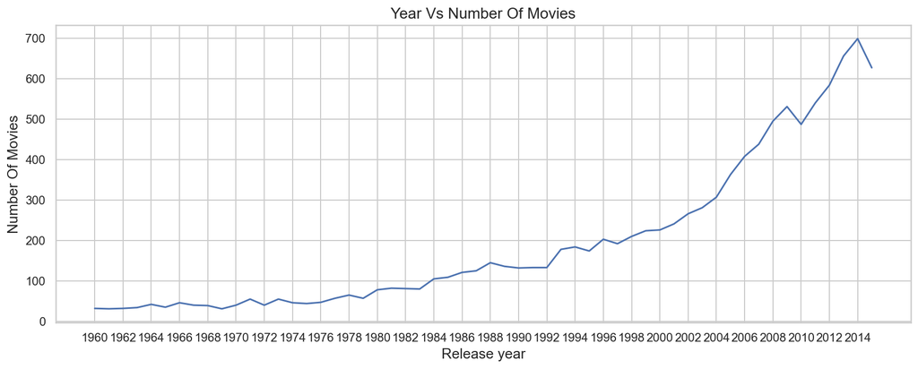

```python
#count the number of movies in each year
data=df1.groupby('release_year').count()['id']
data.plot(xticks = np.arange(1960,2016,2))
sns.set(rc={'figure.figsize':(14,5)})
plt.title("Year Vs Number Of Movies",fontsize = 14)
plt.xlabel('Release year',fontsize = 13)
plt.ylabel('Number Of Movies',fontsize = 13)
#set the style sheet
sns.set_style("whitegrid")
```

**Task 2: Check change in revenue over the years**

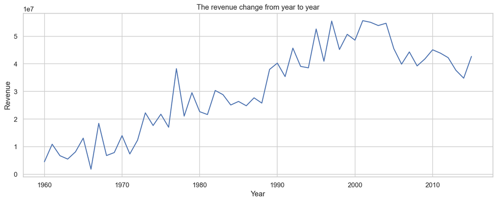

```python
# Revenue change per release year
revenues = df1.groupby('release_year')['revenue'].mean()

plt.plot(revenues)
plt.title('The revenue change from year to year')
plt.xlabel('Year')
plt.ylabel('Revenue')

plt.show()
```

Per the graphical output, there is a notable increase in revenue over the years.

**Taks 3: In which months were the most/least movies released?**

```python
number_of_release=df1['release_date'].dt.month.value_counts().sort_index()
number_of_release
```

```
1      916
2      687
3      821
4      797
5      808
6      826
7      798
8      916
9     1330
10    1148
11     814
12     981
Name: release_date, dtype: int64
```

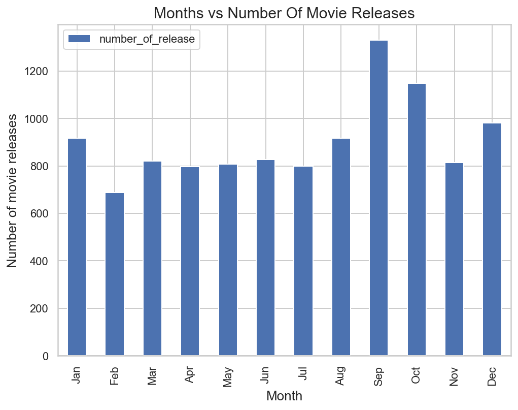

```python
months=['Jan','Feb','Mar','Apr','May','Jun','Jul','Aug','Sep','Oct','Nov','Dec']
number_of_release = pd.DataFrame(number_of_release)
number_of_release['month'] = months
#change the column name of the new dataframe 'number_of_release'
number_of_release.rename(columns = {'release_date':'number_of_release'},inplace=True)

number_of_release.plot(x='month',kind='bar',fontsize = 11,figsize=(8,6))
#set the labels and titles of the plot.
plt.title('Months vs Number Of Movie Releases',fontsize = 15)
plt.xlabel('Month',fontsize = 13)
plt.ylabel('Number of movie releases',fontsize = 13)
```

From a perspective that includes all years, September seems to be leading in number of movies released, followed by October, December then January.

**Task 4: Which genre has the highest number of movies?**

```python
#creating a function, data, which will split the string and return the count of each genre.
def data(x):
    #concatenate all the rows of the genres.
    data_plot = df[x].str.cat(sep = '|')
    data = pd.Series(data_plot.split('|'))
    #conts each of the genre and return.
    info = data.value_counts(ascending=False)
    return info
total_genre_movies = data('genres')
print(total_genre_movies)
```

```
Drama              1757
Comedy             1358
Thriller           1205
Action             1086
Adventure           749
Romance             667
Crime               652
Science Fiction     520
Horror              463
Family              425
Fantasy             396
Mystery             344
Animation           201
Music               136
History             129
War                 119
Western              52
Documentary          35
Foreign              13
TV Movie              1
dtype: int64
```

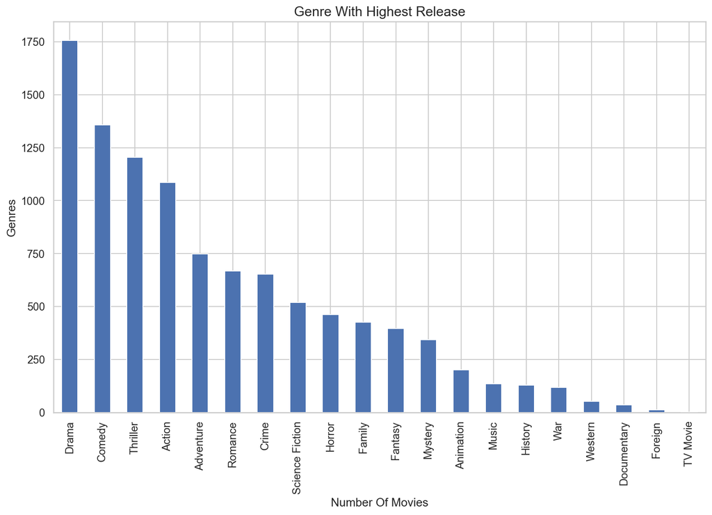

```python
#plot a 'bar' plot using plot function for 'genre vs number of movies'.
total_genre_movies.plot(kind= 'bar',figsize = (13,8),fontsize=12)
#setup the title and the labels of the plot.
plt.title("Genre With Highest Release",fontsize=15)
plt.xlabel('Number Of Movies',fontsize=13)
plt.ylabel("Genres",fontsize= 13)
```

Drama seems to have the most movie produuctions and TV Movies genre, the least.

**Task 5: Which director has produced the most movies?**

```python
df['director'].value_counts().head(n=10)
```

```
Steven Spielberg     27
Clint Eastwood       24
Ridley Scott         21
Woody Allen          18
Martin Scorsese      17
Steven Soderbergh    17
Tim Burton           16
Oliver Stone         15
Robert Zemeckis      15
Renny Harlin         15
Name: director, dtype: int64
```

**Task 6: How does budget and popularity put in for a particular movie or genre relate with revenue generated?**

Considering the the high revenue movies, i.e., ones whose revenue falls above the 50th percentile, and putting this data in a dataframe:

```python
high_revenue = df.revenue.quantile(.50)
high_rev_df = df[df.revenue > high_revenue]
high_rev_df.revenue.describe()
```

```
count    1.927000e+03
mean     1.992166e+08
std      2.130962e+08
min      4.480678e+07
25%      7.484447e+07
50%      1.242721e+08
75%      2.321503e+08
max      2.781506e+09
Name: revenue, dtype: float64
```

**Trying to discover the correlation between different variables. Particular variables of interest are:'popularity', 'vote_average', and 'budget'.**

**Scatterplots and correlation calculation will be used to perform this analysis.**

**Task 6(i): Popularity vs Revenue**

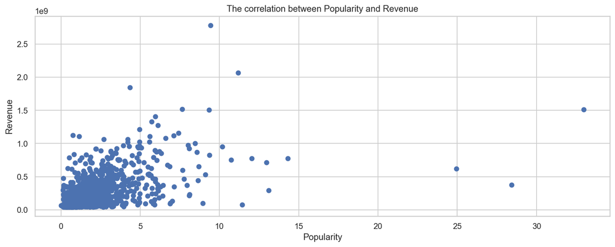

```python
#Scatterplot showing relationship between popularity and revenue
plt.scatter(x=high_rev_df.popularity, y=high_rev_df.revenue)
plt.title('The correlation between Popularity and Revenue')
plt.xlabel('Popularity')
plt.ylabel('Revenue')

plt.show()
```

To further bring out the correlation between popularity and revenue:

```python
# Calculate the correlation between 'popularity' and 'revenue'
high_rev_df[['popularity', 'revenue']].corr()
```

|  | popularity | revenue |
| --- | --- | --- |
| popularity | 1.000000 | 0.557369 |
| revenue | 0.557369 | 1.000000 |

The correlation between these two variables is 0.55.

**Task 6(ii): Vote_average vs Revenue**

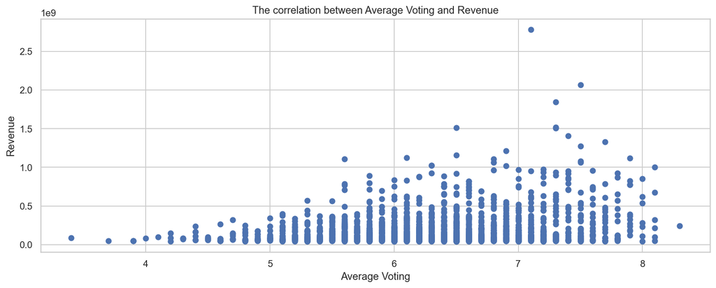

```python
# Draw the scatterplot of the vote_average and revenue
plt.scatter(x=high_rev_df.vote_average, y=high_rev_df.revenue)
plt.title('The correlation between Average Voting and Revenue')
plt.xlabel('Average Voting')
plt.ylabel('Revenue')

plt.show()
```

```python
# Calculate the correlation between 'vote_average' and 'revenue'
high_rev_df[['vote_average', 'revenue']].corr()
```

|  | vote_average | revenue |
| --- | --- | --- |
| vote_average | 1.000000 | 0.245895 |
| revenue | 0.245895 | 1.000000 |

Vote_average and revenue don't seem to have a great correlation: 0.25.

**Task 6 (iii): Budget vs Revenue Comparison**

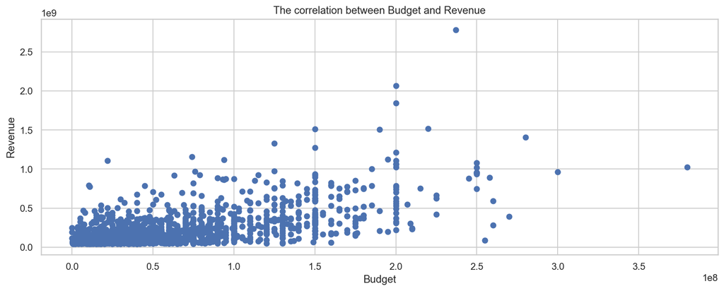

```python
# Draw the scatterplot of the budget and revenue
plt.scatter(x=high_rev_df.budget, y=high_rev_df.revenue)
plt.title('The correlation between Budget and Revenue')
plt.xlabel('Budget')
plt.ylabel('Revenue')

plt.show()
```

```python
# Calculate the correlation between 'vote_average' and 'revenue'
high_rev_df[['budget', 'revenue']].corr()
```

|  | budget | revenue |
| --- | --- | --- |
| budget | 1.000000 | 0.627378 |
| revenue | 0.627378 | 1.000000 |

There is a relatively strong correlation between budget and revenue: 0.63

```python
#Sorting data release data into decades for further Exploratory analysis by using pd.cut() function.
bins_edges=[1960,1970,1980,1990,2000,2010,2015]
bins_names=['1960s','1970s','1980s','1990s','2000s','2010s']
df.release_year = pd.cut(df.release_year, bins_edges, labels = bins_names)
df.release_year.value_counts()
```

```
2000s    3825
2010s    3116
1990s    1860
1980s    1117
1970s     545
1960s     371
Name: release_year, dtype: int64
```

```python
#Separating Data contained in Cast & Genres into Multiple values Source
# Columns like cast & genres contain several values contained in a single cell separated by the "|" ,
# so we need to separate these values to make a more appropriate analysis.
def seprate_values(col):
    new_cols=(df[col].str.split('|', expand=True).rename(columns=lambda x: f"{col}_{x+1}"))
    return new_cols
df_gen = seprate_values('genres')
df_cast = seprate_values('cast')
df['cast'],df['genres']=df_cast['cast_1'],df_gen['genres_1']
display(df['cast'].value_counts().nlargest(10))
print('-'*60)
display(df['genres'].value_counts().nlargest(10))
```

```
Nicolas Cage             50
Robert De Niro           42
Bruce Willis             39
Clint Eastwood           38
Tom Hanks                37
Johnny Depp              37
Sylvester Stallone       37
Jean-Claude Van Damme    35
Steven Seagal            35
Robin Williams           33
Name: cast, dtype: int64
```

```
Drama          2453
Comedy         2319
Action         1590
Horror          915
Adventure       586
Thriller        491
Documentary     432
Animation       403
Crime           381
Fantasy         272
Name: genres, dtype: int64
```

**Task 7: Genre distribution over the years by popularity**

```python
df.groupby(["release_year","genres"])['popularity'].size().unstack()
```

| genres release_year | Action | Adventure | Animation | Comedy | Crime | Documentary | Drama | Family | Fantasy | Foreign | History | Horror | Music | Mystery | Romance | Science Fiction | TV Movie | Thriller | War | Western |
| --- | --- | --- | --- | --- | --- | --- | --- | --- | --- | --- | --- | --- | --- | --- | --- | --- | --- | --- | --- | --- |
| 1960s | 58 | 31 | 13 | 71 | 17 | 5 | 78 | 4 | 8 | 0 | 2 | 30 | 5 | 7 | 5 | 7 | 1 | 10 | 7 | 11 |
| 1970s | 103 | 34 | 7 | 83 | 31 | 8 | 117 | 3 | 13 | 0 | 3 | 75 | 4 | 10 | 5 | 16 | 3 | 17 | 2 | 10 |
| 1980s | 187 | 86 | 22 | 274 | 39 | 13 | 206 | 10 | 44 | 1 | 0 | 119 | 12 | 11 | 14 | 29 | 8 | 31 | 8 | 2 |
| 1990s | 332 | 103 | 53 | 467 | 72 | 22 | 443 | 29 | 72 | 2 | 10 | 88 | 12 | 20 | 32 | 29 | 9 | 55 | 3 | 4 |
| 2000s | 557 | 213 | 198 | 912 | 135 | 147 | 904 | 42 | 85 | 5 | 9 | 289 | 25 | 38 | 45 | 54 | 27 | 106 | 19 | 8 |
| 2010s | 345 | 117 | 110 | 505 | 86 | 237 | 700 | 56 | 50 | 1 | 20 | 308 | 42 | 39 | 85 | 79 | 30 | 269 | 20 | 7 |

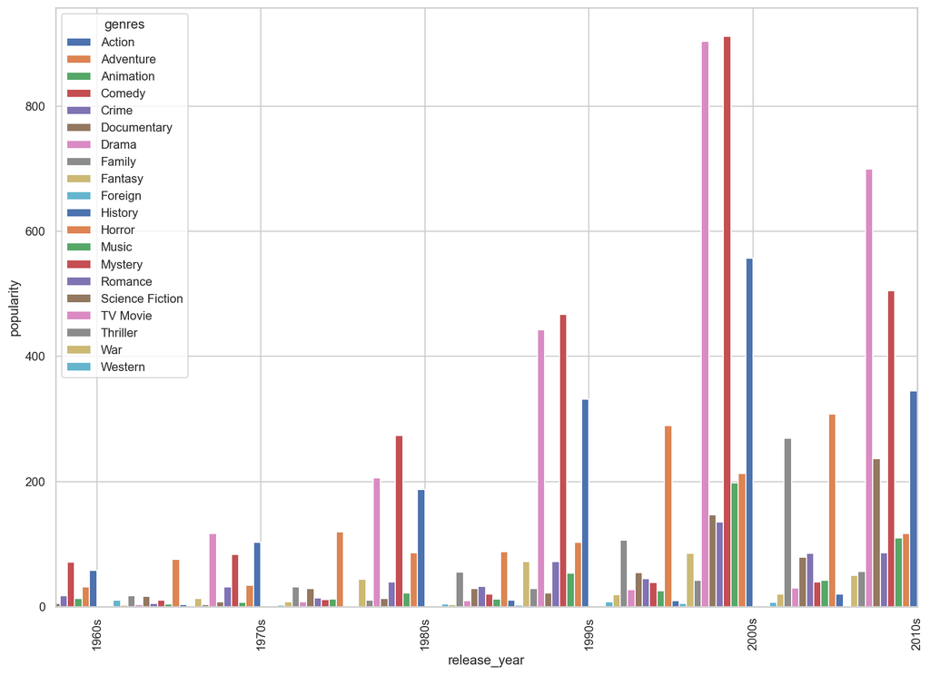

```python
fig, ax = plt.subplots(figsize=(14,10))
df.groupby(["release_year","genres"])['popularity'].size().unstack().plot(kind='bar',ax=ax,width=-.9,align='edge');
ax.set_ylabel('popularity');
```

**Task 8: Movie Runtime Analysis**

```python
# defining a function to find average of a column
def avg_fun(column):
    return df[column].mean()
#calling above function
avg_fun('runtime')
```

```
102.07086324314375
```

The average runtime of a movie is 102 minutes. Now let's find out how movie runtime varies with popularity: What movie lengths are most watched?

```python
#more insights on runtime
df['runtime'].describe()
```

[output not shown]

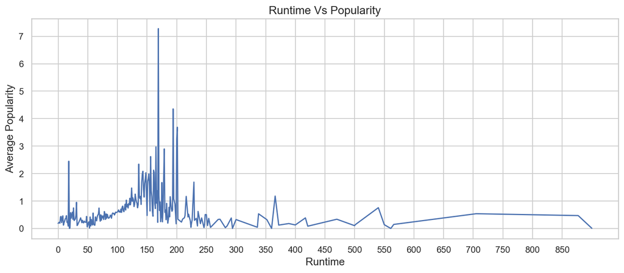

```python
#Group movies based on runtime
#Find the mean popularity related to this and plot.
df.groupby('runtime')['popularity'].mean().plot(figsize = (13,5),xticks=np.arange(0,900,50))

#setup the title of the figure
plt.title("Runtime Vs Popularity",fontsize = 14)
plt.xlabel('Runtime',fontsize = 13)
plt.ylabel('Average Popularity',fontsize = 13)
#setup the figure size.
sns.set(rc={'figure.figsize':(15,8)})
sns.set_style("whitegrid")
```

**Task 9:Comparing Popularity and Profit**

```
Correlation Between Popularity And Profit :  0.6289906698448982
```

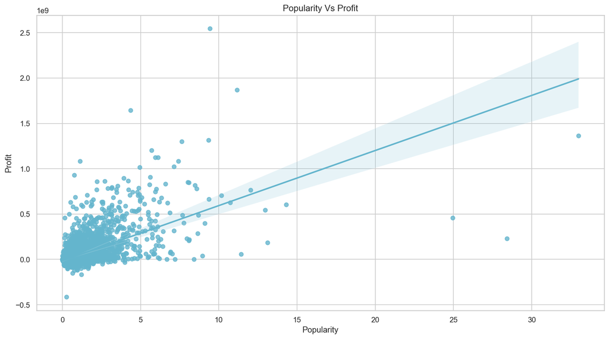

```python
df['Profit'] = df['revenue'] - df['budget']

ax = sns.regplot(x=df['popularity'],y=df['Profit'],color='c')

#setup the title and the labels of the scatter plot.
ax.set_title("Popularity Vs Profit",fontsize=13)
ax.set_xlabel("Popularity",fontsize=12)
ax.set_ylabel("Profit",fontsize=12)

#setup the figure size.
sns.set(rc={'figure.figsize':(6,4)})
sns.set_style("whitegrid")

#find the correlation between them.
data_corr = df.corr()

print("Correlation Between Popularity And Profit : ",data_corr.loc['popularity','Profit'])
```

At 0.63, we can conclude that there is a relatively stron correlation between popularity and profits for a movie. More watched movies realize more returns.

**Task 10: Which movies had the highest and least revenue, and their directors?**

```python
import pprint
#defining the function
def calculate(column):
    #for highest value
    high= df1[column].idxmax()
    high_details=pd.DataFrame(df1.loc[high])

    #for lowest value
    low= df1[column].idxmin()
    low_details=pd.DataFrame(df1.loc[low])

    #collecting data in one place
    info=pd.concat([high_details, low_details], axis=1)

    return info
```

```python
#Movies with most and least earned revenue
# I will call the same function **calculate(column)** again for this analysis
calculate('revenue')
```

|  | 1386 | 48 |
| --- | --- | --- |
| id | 19995 | 265208 |
| popularity | 9.432768 | 2.93234 |
| budget | 237000000 | 30000000 |
| revenue | 2781505847 | 0 |
| original_title | Avatar | Wild Card |
| director | James Cameron | Simon West |
| runtime | 162 | 92 |
| genres | Action\|Adventure\|Fantasy\|Science Fiction | Thriller\|Crime\|Drama |
| release_date | 2009-12-10 00:00:00 | 2015-01-14 00:00:00 |
| vote_count | 8458 | 481 |
| vote_average | 7.1 | 5.3 |
| release_year | 2009 | 2015 |
| budget_adj | 240886902.887613 | 27599987.856005 |
| revenue_adj | 2827123750.41189 | 0.0 |
| net_profit | 2544505847 | -30000000 |

**Task 11: What movies had the highest and least runtime?**

```python
calculate('runtime')
```

|  | 3894 | 92 |
| --- | --- | --- |
| id | 125336 | 370687 |
| popularity | 0.006925 | 1.876037 |
| budget | 0 | 0 |
| revenue | 0 | 0 |
| original_title | The Story of Film: An Odyssey | Mythica: The Necromancer |
| director | Mark Cousins | A. Todd Smith |
| runtime | 900 | 0 |
| genres | Documentary | Fantasy\|Action\|Adventure |
| release_date | 2011-09-03 00:00:00 | 2015-12-19 00:00:00 |
| vote_count | 14 | 11 |
| vote_average | 9.2 | 5.4 |
| release_year | 2011 | 2015 |
| budget_adj | 0.0 | 0.0 |
| revenue_adj | 0.0 | 0.0 |
| net_profit | 0 | 0 |

The movie with the highest runtime is titled 'The Story of Film: An Odyssey' at 900 minutes.

**Task 12: What are some characteristics of movies with highest revenues i.e., what were the budgets, who are the actors, under what genres do they fall.**

Further considering movies who with profits $50M or more :

```python
df.head()
```

|  | id | imdb_id | popularity | budget | revenue | original_title | cast | homepage | director | tagline | ... | runtime | genres | production_companies | release_date | vote_count | vote_average | release_year | budget_adj | revenue_adj | Profit |
| --- | --- | --- | --- | --- | --- | --- | --- | --- | --- | --- | --- | --- | --- | --- | --- | --- | --- | --- | --- | --- | --- |
| 0 | 135397 | tt0369610 | 32.985763 | 150000000 | 1513528810 | Jurassic World | Chris Pratt | http://www.jurassicworld.com/ | Colin Trevorrow | The park is open. | ... | 124 | Action | Universal Studios\|Amblin Entertainment\|Legenda... | 6/9/15 | 5562 | 6.5 | 2010s | 1.379999e+08 | 1.392446e+09 | 1363528810 |
| 1 | 76341 | tt1392190 | 28.419936 | 150000000 | 378436354 | Mad Max: Fury Road | Tom Hardy | http://www.madmaxmovie.com/ | George Miller | What a Lovely Day. | ... | 120 | Action | Village Roadshow Pictures\|Kennedy Miller Produ... | 5/13/15 | 6185 | 7.1 | 2010s | 1.379999e+08 | 3.481613e+08 | 228436354 |
| 2 | 262500 | tt2908446 | 13.112507 | 110000000 | 295238201 | Insurgent | Shailene Woodley | http://www.thedivergentseries.movie/#insurgent | Robert Schwentke | One Choice Can Destroy You | ... | 119 | Adventure | Summit Entertainment\|Mandeville Films\|Red Wago... | 3/18/15 | 2480 | 6.3 | 2010s | 1.012000e+08 | 2.716190e+08 | 185238201 |
| 3 | 140607 | tt2488496 | 11.173104 | 200000000 | 2068178225 | Star Wars: The Force Awakens | Harrison Ford | http://www.starwars.com/films/star-wars-episod... | J.J. Abrams | Every generation has a story. | ... | 136 | Action | Lucasfilm\|Truenorth Productions\|Bad Robot | 12/15/15 | 5292 | 7.5 | 2010s | 1.839999e+08 | 1.902723e+09 | 1868178225 |
| 4 | 168259 | tt2820852 | 9.335014 | 190000000 | 1506249360 | Furious 7 | Vin Diesel | http://www.furious7.com/ | James Wan | Vengeance Hits Home | ... | 137 | Action | Universal Pictures\|Original Film\|Media Rights ... | 4/1/15 | 2947 | 7.3 | 2010s | 1.747999e+08 | 1.385749e+09 | 1316249360 |

5 rows × 22 columns

```python
#Removing (0) from budget and revenue columns
#After exploring the first and last few rows in budget and revenue columns, there are several entries have '0' value, so firstly I will convert those values to NAN then I will remove them from the dataset.

# creating a list of revenue and budget columns
temp_list=['budget', 'revenue']

#this will replace all the value from '0' to NAN in the list
df[temp_list] = df[temp_list].replace(0, np.NAN)

#Removing all the row which has NaN value in temp_list
df.dropna(subset = temp_list, inplace = True)

rows, col = df.shape
print('Now we have only {} no.of movies.'.format(rows-1))
```

```
Now we have only 3854 no.of movies.
```

```python
df.drop_duplicates(keep ='first', inplace=True)
```

```python
#selecting the movies having profit of $50M or more
profit_data = df[df['Profit'] >= 50000000]

#reindexing new data
profit_data.index = range(len(profit_data))

#we will start from 1 instead of 0
profit_data.index = profit_data.index + 1

#printing the changed dataset
profit_data.head(3)
```

|  | id | imdb_id | popularity | budget | revenue | original_title | cast | homepage | director | tagline | ... | runtime | genres | production_companies | release_date | vote_count | vote_average | release_year | budget_adj | revenue_adj | Profit |
| --- | --- | --- | --- | --- | --- | --- | --- | --- | --- | --- | --- | --- | --- | --- | --- | --- | --- | --- | --- | --- | --- |
| 1 | 135397 | tt0369610 | 32.985763 | 150000000.0 | 1.513529e+09 | Jurassic World | Chris Pratt | http://www.jurassicworld.com/ | Colin Trevorrow | The park is open. | ... | 124 | Action | Universal Studios\|Amblin Entertainment\|Legenda... | 6/9/15 | 5562 | 6.5 | 2010s | 1.379999e+08 | 1.392446e+09 | 1363528810 |
| 2 | 76341 | tt1392190 | 28.419936 | 150000000.0 | 3.784364e+08 | Mad Max: Fury Road | Tom Hardy | http://www.madmaxmovie.com/ | George Miller | What a Lovely Day. | ... | 120 | Action | Village Roadshow Pictures\|Kennedy Miller Produ... | 5/13/15 | 6185 | 7.1 | 2010s | 1.379999e+08 | 3.481613e+08 | 228436354 |
| 3 | 262500 | tt2908446 | 13.112507 | 110000000.0 | 2.952382e+08 | Insurgent | Shailene Woodley | http://www.thedivergentseries.movie/#insurgent | Robert Schwentke | One Choice Can Destroy You | ... | 119 | Adventure | Summit Entertainment\|Mandeville Films\|Red Wago... | 3/18/15 | 2480 | 6.3 | 2010s | 1.012000e+08 | 2.716190e+08 | 185238201 |

3 rows × 22 columns

```python
#counting the no.of rows in the new data base
len(profit_data)
```

```
1338
```

```python
#function which will take any column as argument from and keep its track
def data(column):
    #will take a column, and separate the string by '|'
    data = profit_data[column].str.cat(sep = '|')

    #giving pandas series and storing the values separately
    data = pd.Series(data.split('|'))

    #arranging in descending order
    count = data.value_counts(ascending = False)

    return count
#variable to store the retured value
count = data('genres')
#printing top 5 values
count.head()
```

```
Comedy       259
Action       257
Drama        233
Adventure    170
Horror        76
dtype: int64
```

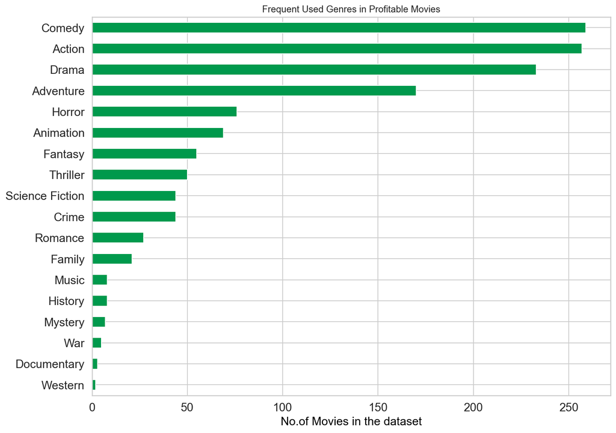

```python
#lets plot the points in descending order top to bottom as we have data in same format.
count.sort_values(ascending = True, inplace = True)

#ploting
pt = count.plot.barh(color = '#00994C', fontsize = 15)

#title
pt.set(title = 'Frequent Used Genres in Profitable Movies')

# on x axis
pt.set_xlabel('No.of Movies in the dataset', color = 'black', fontsize = '15')

#figure size(width, height)
pt.figure.set_size_inches(12, 9)

#ploting the graph
plt.show()
```

From the above visualization, we see that the most profitable movies lie under genres: Comedy, Action, Drama, Adventure in that order, with Western being least.

```python
#Average Budget of the movies
#New function to find average
def profit_avg(column):
    return profit_data[column].mean()
# calling the above function for budget
profit_avg('budget')
```

```
60444957.76083707
```

Average budget for this category of movies(with profits > $50M was 60444957.76083707

```python
#variable to store the retured value
count = data('cast')
#printing top 5 values
count.head()
```

```
Tom Cruise            25
Tom Hanks             20
Sylvester Stallone    18
Denzel Washington     17
Jim Carrey            17
dtype: int64
```

Tom Cruise, Tom Hanks, Sylvester Stallone, Denzel Wwashigton and Jim Carrey rank top five in the top performing movie categories.